# Logements Sociaux à Montréal: Une analyse à partir des données de Montréal Données Ouvertes

Onat Ekinci

Mars 4, 2021

### Introduction

Il existe un besoin criant de logements sociaux au Québec ([Crise du logement social - Radio Canada](https://ici.radio-canada.ca/nouvelle/1771979/logement-social-crise-montreal-quebec-gatineau)) et les besoins ne cessent d’augmenter en raison de la spéculation immobilière des derniers décennies ([Spéculation Immobilière - IRIS](https://cdn.iris-recherche.qc.ca/uploads/publication/file/Spe_culation_immobilie_re_-_Logement_locatif_WEB.pdf))

Une analyse créée à partir des données dans le site web: [Montréal Données Ouvertes](https://donnees.montreal.ca/ville-de-montreal/logements-sociaux)

Les données sont catégorisées par type de projet, soit:

**HLM** : Logements publics gérés par l’Office municipal d’habitation de Montréal, dont le loyer est fixé à 25 % des revenus du ménage. Cette catégorie inclut la Corporation des Habitations Jeanne-Mance.

**OMHM** : Logements publics abordables issus de projets de l’Office municipale d’habitation de Montréal hors programme HLM et gérés sous une forme s’apparentant aux OBNL avec la participations des résidents.

**SHDM** : logements locatifs publics et abordables appartenant à la Société d’habitation et de développement de Montréal et dont certains projets peuvent être gérés par un OBNL.

**OBNL** : Logements locatifs possédés et gérés par un organisme à but non lucratif et qui visent une clientèle ayant des difficultés à se loger convenablement. Les OBNL offrent parfois du soutien communautaire à leurs locataires.

**Coop** : Logements appartenant à une coopérative qui les louent à ses membres. Les coopératives voient à offrir des logements de qualité à prix abordables tout en favorisant une mixité socio-économique dans les projets.

Dans l’analyse, on utilise les librairies sf, tidyverse et ggtext:

```r
library(sf)
library(tidyverse)
library(ggtext)
```

Il faut téléchager les fichiers shape du site web de Montréal Données Ouvertes:

```r
setwd("C:\\Users\\O4000\\Documents\\r_geospatial\\logement_social")
mtl_hlm <- st_read("logsoc_donneesouvertes_20191231.shp")  #read the shapefile
print(mtl_hlm[1:15], n = 6)
```

```
## Simple feature collection with 2754 features and 15 fields
## geometry type:  POINT
## dimension:      XY
## bbox:           xmin: 269255.9 ymin: 5029845 xmax: 305647.3 ymax: 5061670
## projected CRS:  NAD83 / MTM zone 8
## First 6 features:
##   numero          nom_projet     nom_rue nb_log hlm_famill hlm_pa hlm_autres
## 1      3       Saint-Sulpice     Louvain    150        148      0          2
## 2      6      Adrien Trudeau         10e     32          0     32          0
## 3      7         Montmorency Grand Trunk     80          0     74          6
## 4     16     Place Normandie   Chartrand    168        167      0          1
## 5     19 Étienne-Desmarteaux         13e    117          0    108          9
## 6     22          Parc-Royal   Elizabeth     33          0     32          1
##   projettype type_prog an_orig an_effect                    arrond villelie qr
## 1        HLM      <NA>    1971        NA     Ahuntsic-Cartierville     <NA>  5
## 2        HLM      <NA>    1994        NA                   Lachine     <NA> 70
## 3        HLM      <NA>    1978        NA              Le Sud-Ouest     <NA> 47
## 4        HLM      <NA>    1972        NA             Montréal-Nord     <NA> 61
## 5        HLM      <NA>    1978        NA Rosemont–La Petite-Patrie     <NA> 17
## 6        HLM      <NA>    1979        NA             Saint-Laurent     <NA> 57
##          localisati                 geometry
## 1 Aire de diffusion POINT (293406.7 5046286)
## 2 Aire de diffusion POINT (291311.1 5034017)
## 3 Aire de diffusion POINT (300052.5 5038462)
## 4 Aire de diffusion POINT (295167.3 5053772)
## 5 Aire de diffusion   POINT (298545 5046498)
## 6 Aire de diffusion   POINT (290573 5042778)
```

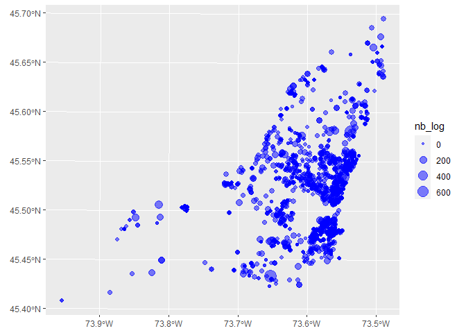

```r
ggplot(mtl_hlm) + geom_sf(aes(size = nb_log), fill = "red", color = "blue", alpha = 0.5)
```

On observe qu’il y a 15 champs, dont le type du projet, le nombre de logements par projet, le nom de l’arrondissement.

Les données GIS sont sous format point. Pour ajouter la carte de Montréal dans l’arrière-plan, on doit aussi télécharger le fichier shape pour des régions administratives ([Montréal Polygone](https://donnees.montreal.ca/ville-de-montreal/polygones-arrondissements))

```r
mtl_adm <- st_read("LIMADMIN.shp")
```

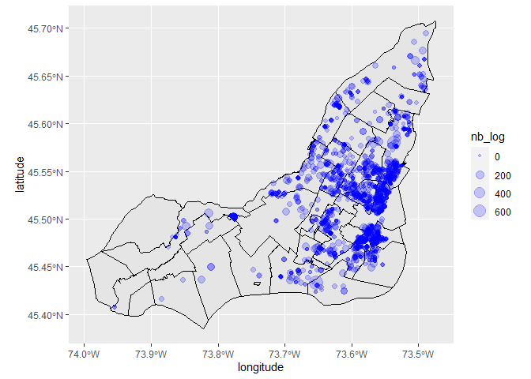

```r
ggplot(mtl_adm) +
  geom_sf(color = "black") +
  geom_point(data = mtl_hlm, aes(x = longitude , y = latitude, size = nb_log), fill = "red", color = "blue", alpha = 0.2)
```

On observe qu’il y a une concentration de logements sociaux dans le sud de l’ile de Montréal.

On peut également spécifier le type de logement social sur la carte:

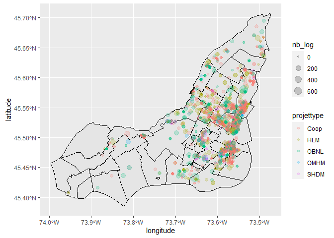

```r
ggplot(mtl_adm) +
  geom_sf(color = "black") +
  geom_point(data = mtl_hlm, aes(x = longitude , y = latitude, size = nb_log, color = projettype), alpha = 0.2) +
  scale_fill_gradient(low = "green", high = "red", na.value = NA)
```

La distribution par type de projet sur l’ile de Montréal:

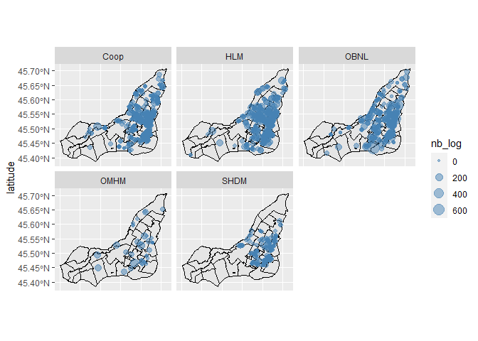

```r
ggplot(mtl_adm) +
  geom_sf(color = "black") +
  geom_point(data = mtl_hlm, aes(x = longitude , y = latitude, size = nb_log), alpha = 0.5, color = "steelblue") +
  facet_wrap(~projettype, nrow = 2) +
    theme(axis.title.x=element_blank(),
        axis.text.x=element_blank(),
        axis.ticks.x=element_blank())
```

### La présence des HLM selon l’arrondissement à Montréal

Si on voulait voir la distribution des HLM selon l’arrondissement:

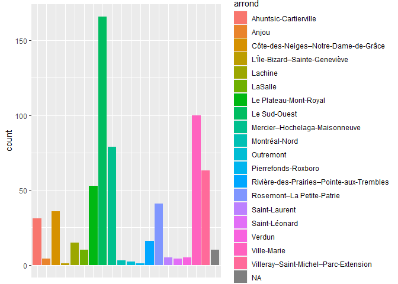

```r
projet_hlm <- filter(mtl_hlm, projettype == "HLM")
ggplot( data = projet_hlm ) +
  geom_bar( mapping = aes( x = arrond, fill = arrond)) +
    theme(axis.title.x=element_blank(),
        axis.text.x=element_blank(),
        axis.ticks.x=element_blank())
```

### La présence des coopératives d’habitation selon l’arrondissement à Montréal

Qu’en est-il des coop?:

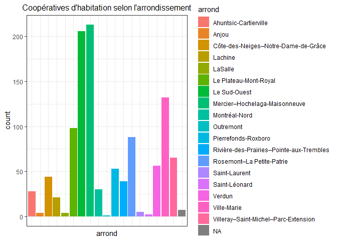

```r
projet_coop <- filter(mtl_hlm, projettype == "Coop")
ggplot( data = projet_coop ) +
  geom_bar( mapping = aes( x = arrond, fill = arrond))+
    labs(
    title = "Coopératives d'habitation selon l'arrondissement") +
  theme_bw() +
  theme(
    axis.text.x=element_blank(),
    axis.ticks.x=element_blank(),
    plot.title = element_markdown(size = 12, lineheight = 2, hjust=0.5)
  )
```

Cette fois-ci c’est le Mercier-Hochelaga-Maisonneuve qui vient en première, mais le constat est le même que pour les HLM, une concentration dans la partie sud de Montréal.

### La construction des logements sociaux à Montréal dans les dernières années

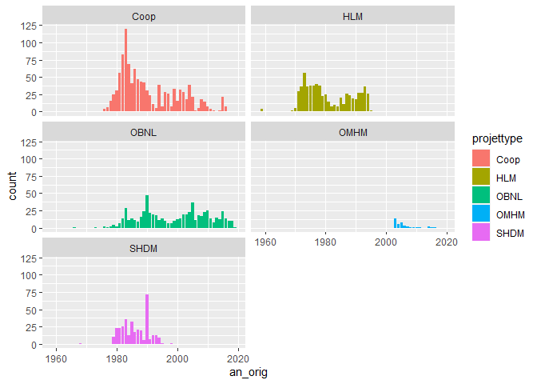

```r
ggplot( data = mtl_hlm ) +
  geom_bar( mapping = aes( x = an_orig, fill = projettype)) +
    facet_wrap(~projettype, nrow = 3)
```

On constate que la construction des logements sociaux a beaucoup diminué dans les derniers décennies. Ce sont seulement des OBNL qui semblent avoir une courbe de croissance constante, bien que limitée.

On pourrait aussi faire une analyse selon le type de projet:

#### La construction des HLM à Montréal

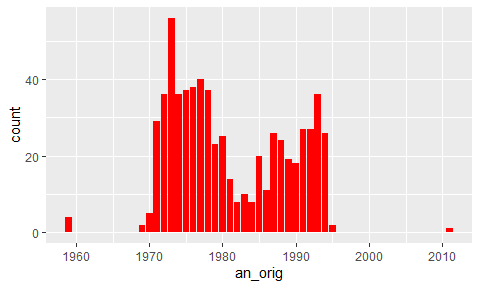

```r
projet_hlm <- filter(mtl_hlm, projettype == "HLM")
ggplot( data = projet_hlm ) +
  geom_bar( mapping = aes( x = an_orig), fill = "red")
```

Dans la figure, on peut constater qu’il n’y a quasiment pas eu de construction de HLM depuis 1995.

#### La construction des coop d’habitation à Montréal

Le constat pour les coop est également décourageant, la construction reste assez faible, surtout dans les derniers décennies:

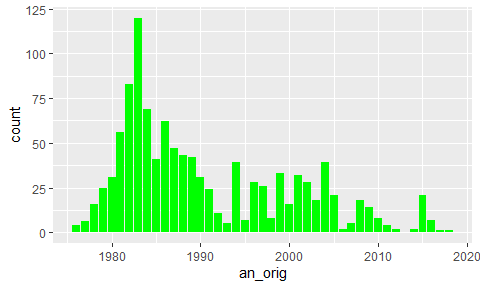

```r
projet_hlm <- filter(mtl_hlm, projettype == "Coop")
ggplot( data = projet_hlm ) +
  geom_bar( mapping = aes( x = an_orig), fill = "green")
```

#### La construction des OBNL à Montréal

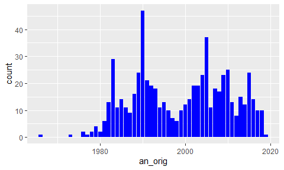

```r
projet_hlm <- filter(mtl_hlm, projettype == "OBNL")
ggplot( data = projet_hlm ) +
  geom_bar( mapping = aes( x = an_orig), fill = "blue")
```

## Le type de logements sociaux à Montréal

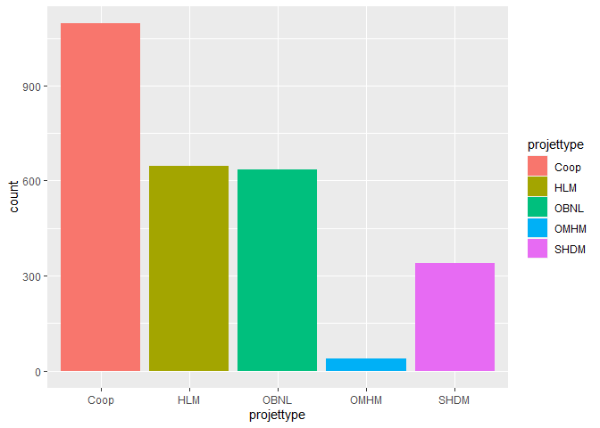

```r
arrondissement_sud_ouest <- filter(mtl_hlm, arrond == "Le Sud-Ouest")
ggplot( data = mtl_hlm) + geom_bar( mapping = aes( x = projettype, fill = projettype))
```

### CONCLUSION

La pénurie de logements sociaux à Montréal peut facilement être observé à partir des données publiques. On constate aussi qu’Il y a eu très peu de construction dans les dernières décennies.

La priorité des politiques de logement au Canada a toujours été de favoriser l’accès à la propriété, plutôt que d’assister les locataires [Arsenault, 2018]. Selon [Londerville & Steele, 2014], les dépenses fiscales annuelles, comme la non-imposition du gain en capital sur les résidences principales, visant à soutenir les propriétaires, sont augmentés de 7 à 9 milliards de dollars entre 1993 et 2013.

### REFERENCES

Gabriel Arsenault, L’Économie sociale au Québec. Une perspective politique, Presses de l’Université du Québec, coll. « Politeia », 2018, 256 pages